# Classical Tests

Everton da Costa

2025-10-20

# Classical tests

## Executive Summary & Core Competencies

**The Challenge**: Standard statistical tests, like the Likelihood Ratio (LR) test, can produce misleading or nonsensical results (e.g., negative test statistics) when applied to complex time series models like the $\beta\text{ARMA}$ if not implemented carefully. This issue arises when comparing nested models (e.g., $\beta\text{ARMA}(1,4)$ vs. $\beta\text{ARMA}(1,0)$) that are conditioned on different amounts of initial data, a subtle but critical detail often overlooked by standard software packages.

**The Solution**: This report demonstrates the correct implementation of the LR, Rao Score, and Wald tests, following the methodology established by [Costa, E., Cribari-Neto, F., & Scher, V. T. (2024)](https://doi.org/10.1016/j.jhydrol.2024.131489). Using simulated data with a known ground truth, both naive and statistically adjusted versions of the tests are implemented to highlight the problem and validate the correct approach.

**The Impact**: The analysis confirms that only the adjusted tests produce reliable inferences, successfully avoiding the pitfalls of the naive approach. This work showcases the ability to go beyond off-the-shelf tools to ensure statistical rigor and build trustworthy models.

**Core Competencies Demonstrated**

- **Statistical Theory**: Deep understanding of the theoretical underpinnings and assumptions of the Wald, Likelihood Ratio, and Rao Score tests.
- **Methodological Rigor**: Identifying and correcting for subtle issues in statistical procedures that can lead to invalid conclusions.
- **R Programming & Simulation**: Translating complex statistical formulas from a research paper into functional R code and using simulated data to validate the implementation.
- **Model Validation**: Demonstrating a sophisticated approach to hypothesis testing that ensures the selection of statistically significant model features.

## Introduction

In modern data science, it’s easy to fit complex models using off-the-shelf libraries. However, ensuring the statistical foundations of a model are sound is critical for building trust and avoiding incorrect conclusions. This vignette demonstrates a deeper level of model validation: implementing and comparing classical hypothesis tests (Wald, LR, Score) for $\beta\text{ARMA}$ model. The focus is on handling a subtle methodological challenge that can lead to misleading results, showcasing a commitment to rigorous and reliable modeling.

In $\beta\text{ARMA}$ models, the conditional log-likelihood sum starts from $t=a+1$, where $a = \max(p,q)$ with $p$ and $q$ being the AR and MA orders, respectively. A crucial issue arises if $a$ for the null model ($a_N$) is less than $a$ for the non-null/unrestricted model ($a_{NN}$). This report will illustrate such a scenario ($a_N < a_{NN}$) and show how to apply the tests correctly. If ignored, this technical issue can lead to unreliable p-values and, in a real-world setting, could cause a data scientist to make incorrect decisions about which model features are significant.

The numerical results presented here replicate the example in Section 3.1 of [Costa, E., Cribari-Neto, F., & Scher, V. T. (2024)](https://doi.org/10.1016/j.jhydrol.2024.131489).

## Data Simulation

We begin by loading the R packages required for this analysis. The setup includes the `BARMAJournalHydrology2024` package, which contains the functions needed for simulating data and performing the classical tests. Additionally, we use forecast for time series objects, `ggplot2` for creating visualizations, `zoo` for managing date formats, `gridExtra` for arranging plots, and `dplyr` for data manipulation.

```r
library(BARMAJournalHydrology2024)
library(forecast)   # time series
library(ggplot2)    # plotting
library(zoo)        # yearmon handling
library(gridExtra)  # grid.arrange for plots

library(dplyr)
```

To objectively validate the performance of the statistical tests, we first generate 250 observations from a $\beta\text{AR}(1)$ process, meaning the true model has no moving average (MA) components. A correctly implemented test should, therefore, fail to find significance for any MA parameters.

We simulate a time series of length $n=250$ from a $\beta$AR(1) process. The true parameters are: $\alpha = 0$, $\varphi_1 = 0.4$, $\phi = 20$. A logit link function is assumed for $g(\mu_t)$.

```r
n <- 250
alpha_true <- 0
varphi_true <- 0.4
theta_true <- NA # Implies no MA part in simu_barma
phi_true <- 20

# Link function
link_function <- "logit"

# Reproducibility
seed <- 2
```

```r
set.seed(seed) # Ensure reproducibility for this specific simulation
y <- simu_barma(
  n = n,
  alpha = alpha_true,
  varphi = varphi_true,
  theta = theta_true,
  phi = phi_true,
  link = link_function
)
```

## Data Visualization

We’ll set up some standard configurations for our `ggplot2` plots. This helps ensure a consistent and clean appearance for all visualizations in the vignette.

```r
# Series size and end time
sample_size <- length(y)
end_time_series <- time(y)[sample_size] + 1

# Size font of the plot
ggplot_size_font <- 9

# ggplot theme
ggplot_theme <- theme(
  title = element_text(size = ggplot_size_font),
  axis.text = element_text(size = ggplot_size_font),
  axis.title = element_text(size = ggplot_size_font),
  legend.text = element_text(size = ggplot_size_font),
  legend.title = element_text(size = ggplot_size_font)
  )

# y-axis scale
ggplot_scale_y <-
  scale_y_continuous(
    breaks = seq(0, 1, 0.10),
    limits = c(0, 1)
  )

# x-axis scale
ggplot_scale_x <- scale_x_continuous(
  breaks = seq(0, sample_size, 25),
  limits = c(0, sample_size)
)
```

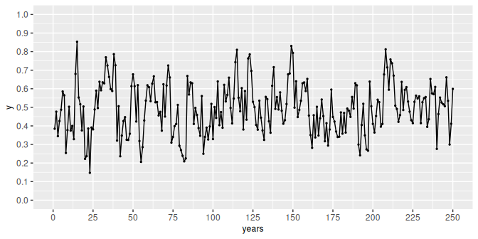

Simulated time series from a $\beta$-AR(1) process.

```r
# Data frame for ggplot
y_df <- data.frame(y = y, years = seq_along(y))

# Time series plot
ggplot_data_simulation <- ggplot(y_df, aes(years, y)) +
  geom_point(size = 0.5) +
  geom_line(aes(group = 1)) +
  ggplot_scale_x +
  ggplot_scale_y +
  ggplot_theme
```

## Parameter Estimation

Here, we set up the core of our hypothesis test. We fit two models to the simulated data:

- **The Unrestricted Model**: A $\beta\text{ARMA}(1,4)$ model, which includes four MA parameters that we hypothesize are zero.
- **The Restricted Model**: A $\beta\text{ARMA}(1,0)$ model, which represents our null hypothesis ($H_0$) where the MA parameters are forced to be zero.

The key issue, as noted by [Costa, E., Cribari-Neto, F., & Scher, V. T. (2024)](https://doi.org/10.1016/j.jhydrol.2024.131489), is that these models are conditioned on a different number of initial observations ($a_{NN} = 4$ vs. $a_{N} = 1$). The following tests will show how to handle this discrepancy.

Here, $a_{NN} = \max(1,4) = 4$ for the unrestricted model, and $a_N = \max(1,0) = 1$ for the restricted model.

```r
ar_vec <- 1
ma_vec <- 1:4
rest_ma <- 3:6
```

```r
fit <- barma_classical_tests(
  y = y,
  ar = ar_vec,
  ma = ma_vec,
  rest_ma = rest_ma
)

fit_unrest <- fit$unrestricted_model
fit_rest <- fit$ar_restricted_model

unrest_coeff <- round(fit_unrest$model, 4)
rest_coeff <- round(fit_rest$model, 4)
```

```r
# Unrestricted Model BARMA(1,4) Coefficients:
knitr::kable(
  unrest_coeff,
  caption =
    "Estimated coefficients for the $\\beta ARMA(1,4)$ model - Unrestricted Model."
)
```

Estimated coefficients for the $\beta ARMA(1,4)$ model - Unrestricted Model.

|  | Estimate | Std. Error | z value | Pr(>\|z\|) |
| --- | --- | --- | --- | --- |
| alpha | -0.0102 | 0.0379 | 0.2700 | 0.7872 |
| varphi1 | 0.3936 | 0.7397 | 0.5321 | 0.5947 |
| theta1 | 0.0564 | 0.7403 | 0.0762 | 0.9392 |
| theta2 | 0.0319 | 0.3378 | 0.0945 | 0.9247 |
| theta3 | 0.0019 | 0.1657 | 0.0118 | 0.9906 |
| theta4 | 0.0346 | 0.0858 | 0.4036 | 0.6865 |
| phi | 15.8319 | 1.3853 | 11.4283 | 0.0000 |

```r
# Restricted Model BARMA(1,0) Coefficients:
knitr::kable(
  rest_coeff,
  caption =
    "Estimated coefficients for the $\\beta ARMA(1,0)$ model - Restricted Model."
)
```

Estimated coefficients for the $\beta ARMA(1,0)$ model - Restricted Model.

|  | Estimate | Std. Error | z value | Pr(>\|z\|) |
| --- | --- | --- | --- | --- |
| alpha | -0.0108 | 0.0311 | 0.3486 | 0.7274 |
| varphi1 | 0.4523 | 0.0529 | 8.5559 | 0.0000 |
| phi | 15.9138 | 1.3843 | 11.4962 | 0.0000 |

## Classical Hypothesis Tests: LR, Rao Score, and Wald

This section details the application of the Wald, Likelihood Ratio (LR), and Rao Score tests. All three tests are employed to evaluate a common hypothesis regarding the parameters of the $\beta\text{ARMA}$ model. Specifically, we test the joint significance of the first four moving average (MA) parameters by comparing an unrestricted $\beta\text{ARMA}(1,4)$ model against a restricted $\beta\text{ARMA}(1,0)$ model.

The null hypothesis: $H_0: \theta_1 = \theta_2 = \theta_3 = \theta_4 = 0$. The alternative hypothesis, $H_1$, is that at least one of these $\theta_j$ parameters (for $j=1,2,3,4$) is non-zero.

Under the null hypothesis, the test statistics for the Wald, LR, and Rao Score tests asymptotically follow a $\chi^2$ (chi-squared) distribution. Since there are four parameters being restricted under $H_0$ (namely $\theta_1, \theta_2, \theta_3, \theta_4$), the degrees of freedom for this $\chi^2$ distribution is 4.

A key focus of this report, following the findings of [Costa, E., Cribari-Neto, F., & Scher, V. T. (2024)](https://doi.org/10.1016/j.jhydrol.2024.131489), is addressing the methodological challenge that arises when the number of initial observations used for conditioning differs between the null model ($a_N = \max(1,0) = 1$) and the unrestricted model ($a_{NN} = \max(1,4) = 4$). We will demonstrate both standard and adjusted versions of these tests designed for such $a_N < a_{NN}$ scenarios to ensure reliable inference.

### Likelihood Ratio Test

```r
# Classical tests results
classical_tests_results <- fit$classical_tests
```

```r
# Extract all LR statistics and p-values
LR1_stat <- classical_tests_results$LR_naive_res[1]
LR1_pval <- classical_tests_results$LR_naive_res[2]

LR2_stat <- classical_tests_results$LR_m0_res[1]
LR2_pval <- classical_tests_results$LR_m0_res[2]

LR3_stat <- classical_tests_results$LR_mfun_res[1]
LR3_pval <- classical_tests_results$LR_mfun_res[2]

# Organize results into a data frame
lr_results_df <- data.frame(
  Output = c(names(LR1_stat), names(LR2_stat), names(LR3_stat)),
  Test_Version = c("LR1 (Naive)", "LR2 (Adjusted)", "LR3 (Recommended)"),
  Statistic = c(LR1_stat, LR2_stat, LR3_stat),
  p_value = c(LR1_pval, LR2_pval, LR3_pval)
)

rownames(lr_results_df) <- NULL

# Create a table
knitr::kable(
  lr_results_df,
  caption = "Likelihood Ratio (LR) results for the joint significance of MA
  parameters $(H_0: \\theta_1=\\theta_2=\\theta_3=\\theta_4=0)$.",
  col.names = c("Output", "Test Version", "Statistic", "p-value"),
  digits = 4,
  booktabs = TRUE,
  linesep = ""
)
```

Likelihood Ratio (LR) results for the joint significance of MA parameters $(H_0: \theta_1=\theta_2=\theta_3=\theta_4=0)$.

| Output | Test Version | Statistic | p-value |
| --- | --- | --- | --- |
| LR_naive_stat | LR1 (Naive) | -5.3433 | 1.0000 |
| LR_m0_stat | LR2 (Adjusted) | 0.3090 | 0.9892 |
| LR_mfun_stat | LR3 (Recommended) | 0.3009 | 0.9898 |

The results are striking. The naive **LR1** statistic is negative $(-5.3433)$, a statistically impossible result that highlights the failure of the standard approach. In contrast, the adjusted **LR2** and **LR3** statistics are positive and yield high p-values, correctly indicating that the null hypothesis should not be rejected.

### Rao Score Test

The Rao Score test, provides another way to test hypotheses, requiring only the estimation of the restricted model. It examines the gradient (score) of the log-likelihood function at the restricted estimates. Similar to the LR test, adjustments are crucial when $a_N < a_{NN}$ to ensure accurate inference, as discussed by [Costa, E., Cribari-Neto, F., & Scher, V. T. (2024)](https://doi.org/10.1016/j.jhydrol.2024.131489). The output below presents:

Score Vectors:

- `ar_score_vec_arma_naive`: The score vector, with parameters estimated using its own $a_N$.
- `ar_score_vec_arma_mfun`: The score vector, with parameters estimated using $a_{NN}$.

Score Test Statistics:

**Naive Versions** (using score_vec_naive and mat_vcov_naive from model with $a_N$):

- `R_naive_res` (Sr$^*$): A form of the Score statistic that can exhibit size distortions in the $a_N < a_{NN}$ case.
- `R_expanded_res` (Se$^*$): The the Score statistic, also using $a_N$.

**Recommended Versions**:

- `R_mfun_res` (Sr): The reduced form of the Score statistic, with parameters estimated using $a_{NN}$.
- `R_exp_mfun_res` (Se): The expanded form of the Score statistic, with parameters estimated using $a_{NN}$.

The R code below displays these components. For detailed theoretical justifications and the precise nature of the ‘mfun’ object, readers should consult [Costa, E., Cribari-Neto, F., & Scher, V. T. (2024)](https://doi.org/10.1016/j.jhydrol.2024.131489).

```r
# Extract all Score statistics and p-values
Sr_star_stat <- classical_tests_results$R_naive_res[1]
Sr_star_pval <- classical_tests_results$R_naive_res[2]

Se_star_stat <- classical_tests_results$R_expanded_res[1]
Se_star_pval <- classical_tests_results$R_expanded_res[2]

Sr_stat <- classical_tests_results$R_mfun_res[1]
Sr_pval <- classical_tests_results$R_mfun_res[2]

Se_stat <- classical_tests_results$R_exp_mfun_res[1]
Se_pval <- classical_tests_results$R_exp_mfun_res[2]

# --- 2. Display the diagnostic score vectors ---
cat("Score Vector (conditioned on a_N):\n")
```

```
#> Score Vector (conditioned on a_N):
```

```r
print(round(fit$ar_restricted_model$ar_score_vec_arma_naive, 4))
```

```
#> [1]  1.6660  0.1062 -0.0165  0.6977 -3.5366  8.3800 -0.0528
```

```r
cat("\nScore Vector (conditioned on a_NN):\n")
```

```
#>
#> Score Vector (conditioned on a_NN):
```

```r
print(round(fit$ar_restricted_model$ar_score_vec_arma_mfun, 4))
```

```
#> [1]  0.0000  0.0000 -0.1286  0.6518 -3.5464  8.3098  0.0000
```

```r
# Organize the final test statistics into a data frame
rao_results_df <- data.frame(
  Output = c(
    names(Sr_star_stat),
    names(Se_star_stat),
    names(Sr_stat),
    names(Se_stat)
    ),
  Test_Version = c(
    "Sr* (Naive Reduced)",
    "Se* (Naive Extended)",
    "Sr (Recommended Reduced)",
    "Se (Recommended Extended)"
  ),
  Statistic = c(Sr_star_stat, Se_star_stat, Sr_stat, Se_stat),
  p_value = c(Sr_star_pval, Se_star_pval, Sr_pval, Se_pval)
)

rownames(rao_results_df) <- NULL

# Create the table for the test results
knitr::kable(
  rao_results_df,
  caption = "Rao Score test results for the joint significance of MA parameters
  $(H_0: \\theta_1=\\theta_2=\\theta_3=\\theta_4=0)$.",
  col.names = c("Output", "Test Version", "Statistic", "p-value"),
  digits = 4,
  booktabs = TRUE,
  linesep = ""
)
```

Rao Score test results for the joint significance of MA parameters $(H_0: \theta_1=\theta_2=\theta_3=\theta_4=0)$.

| Output | Test Version | Statistic | p-value |
| --- | --- | --- | --- |
| R_naive_stat | Sr* (Naive Reduced) | 0.4343 | 0.9796 |
| R_exp_stat | Se* (Naive Extended) | 0.3618 | 0.9855 |
| R_mfun_stat | Sr (Recommended Reduced) | 0.3518 | 0.9862 |
| R_exp_mfun_stat | Se (Recommended Extended) | 0.3518 | 0.9862 |

### Wald Test

The Wald test is another method for testing hypotheses about the model parameters. It primarily uses information from the unrestricted model, specifically the parameter estimates and their variance-covariance matrix, to assess the specified null hypothesis $(H_0: \theta_1 = \theta_2 = \theta_3 = \theta_4 = 0)$.

```r
# Extract Wald statistics and p-values
W1_stat <- classical_tests_results$W_res[1]
W1_pval <- classical_tests_results$W_res[2]

W2_stat <- classical_tests_results$W2_res[1]
W2_pval <- classical_tests_results$W2_res[2]

# Organize results into a data frame
wald_results_df <- data.frame(
    Output = c(
    names(W1_stat),
    names(W2_stat)
    ),
  Test_Version = c("W1 (Standard)", "W2 (Adjusted)"),
  Statistic = c(W1_stat, W2_stat),
  p_value = c(W1_pval, W2_pval)
)

rownames(wald_results_df) <- NULL

# Create the polished table
knitr::kable(
  wald_results_df,
  caption = "Wald test results for the joint significance of MA parameters
  $(H_0: \\theta_1=\\theta_2=\\theta_3=\\theta_4=0)$.",
  col.names = c("Output", "Test Version", "Statistic", "p-value"),
  digits = 4,
  booktabs = TRUE,
  linesep = ""
)
```

Wald test results for the joint significance of MA parameters $(H_0: \theta_1=\theta_2=\theta_3=\theta_4=0)$.

| Output | Test Version | Statistic | p-value |
| --- | --- | --- | --- |
| W_stat | W1 (Standard) | 0.2936 | 0.9902 |
| W2_stat | W2 (Adjusted) | 0.2702 | 0.9917 |

## Interpreting the Test Results

The results provide a clear verdict on the importance of using the correct test implementation. Across the board, the adjusted tests ($LR_3$, $S_r$, $S_e$, and both Wald tests) produce high p-values (e.g., $p = 0.9898$ for $LR_3$), leading to the same conclusion: we do not reject the null hypothesis ($H_0$). This is the correct inference, as the data was simulated from a $\beta\text{AR(1)}$ model with no MA components.

In contrast, the naive LR$_1$ statistic produced a negative value, a nonsensical result for a test statistic that should follow a $\chi^2$ distribution. This highlights its unreliability when $a_N < a_{NN}$.

This example confirms the central finding from [Costa, E., Cribari-Neto, F., & Scher, V. T. (2024)](https://doi.org/10.1016/j.jhydrol.2024.131489): using methodologically sound, adjusted tests is critical for accurate inference in these scenarios.

## Conclusion

This vignette successfully demonstrated the implementation of classical Wald, Likelihood Ratio, and Rao Score hypothesis tests for $\beta$ARMA time series models, replicating the findings of [Costa, E., Cribari-Neto, F., & Scher, V. T. (2024)](https://doi.org/10.1016/j.jhydrol.2024.131489).

The key challenge addressed was the methodological issue where the null and alternative models are conditioned on a different number of initial observations. By implementing both naive and adjusted versions of the tests, this analysis confirms that the adjusted procedures are essential for reliable inference.

Core Competencies Showcased:

- **Statistical Theory**: Deep understanding of the theoretical underpinnings of three core statistical tests.
- **Methodological Rigor**: Identifying and correcting for subtle issues in statistical procedures that can impact results.
- **R Programming & Package Development**: Implementing the statistical methodology as a reproducible R package.
- **Validation & Simulation**: Using simulated data with a known ground truth to validate the correctness of the implementation.